# Data Exploration: Samtools vs GATK

Jessica Rowell

9/17/2020

## Exploring the GATK and Samtools datasets

SNPs were called from 266 salmonella isolates using two methods, GATK and Samtools. The input for each SNP calling pipeline is fasta files. The output from each pipeline is a list of the isolates and the number of SNPs called from each.

The data used for exploring the results of these two methods combines the genome ID, the number of SNPs called for each method, and serotype code information.

```
##                        id   sam gatk code               Serotype
## 1    02-0341-M3235-15-037 17143 5114  TEA       Salmonella Miami
## 2  2009K-1733-M347-15-032 12090 3608  JEG Salmonella Enteritidis
## 3 2010K-0038-M3235-15-041 17146 5036  TEA       Salmonella Miami
## 4  2011K-0646-M347-15-049 14152 4230  JAB       Salmonella Agona
## 5  2011K-0688-M347-15-049 14141 4200  JAB       Salmonella Agona
## 6  2011K-1785-M347-14-021 17152 5137  JIX  Salmonella Montevideo
```

There are 69 serotype codes in total. Four of the genomes each has two serotype codes.

```
##                   Genome n
## 1 Sal_JEG_CDC_2010K-0968 2
## 2    Sal_JF6_CFSAN002064 2
## 3    Sal_JFX_CFSAN003307 2
## 4          Sal_JJP_36805 2
```

An initial scatterplot comparing GATK and Samtools SNP calling results shows that most of the data clusters in a roughly linear correlation. There are several outliers to be examined more closely. At this resolution, there doesn’t appear to be clustering on serotype code.

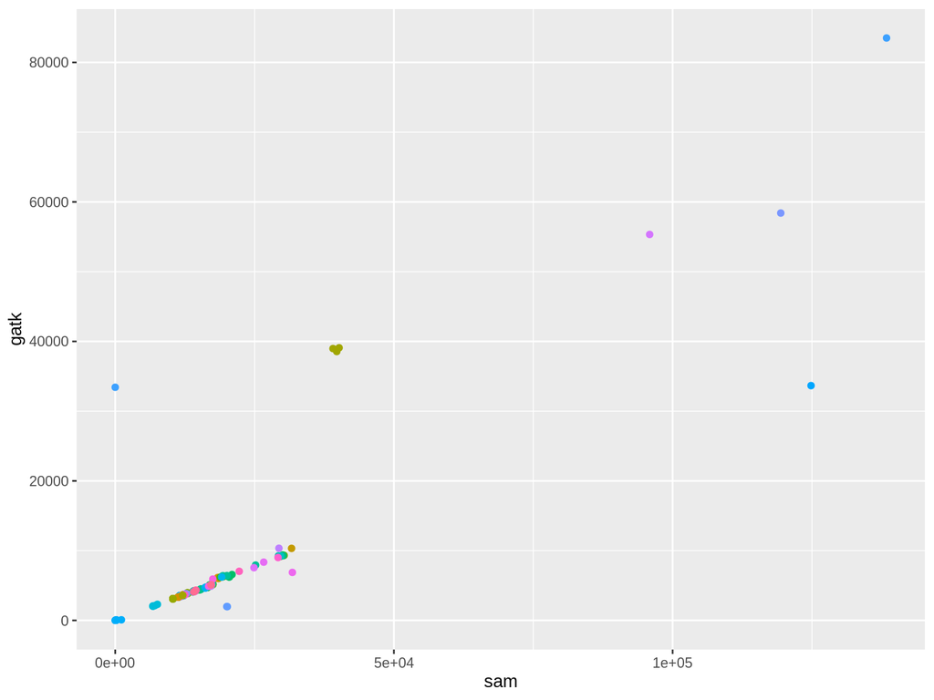

We can see that the two datasets have roughly the same shape. Additionally, they have almost the same number of outliers (GATK: n=42, Samtools: n=41).

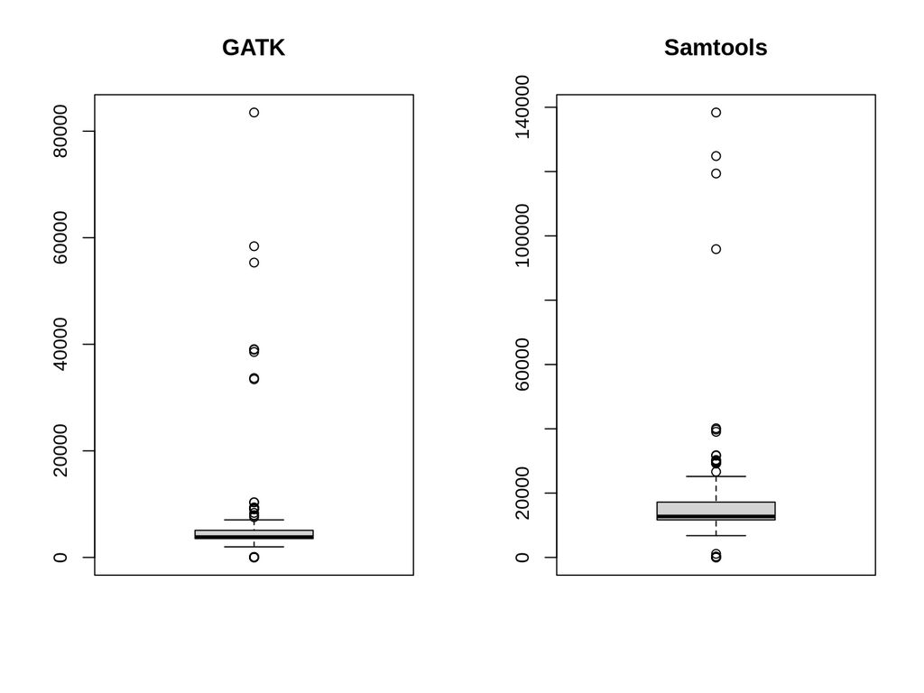

Density plots don’t really give us additional information, but some people prefer them over boxplots.

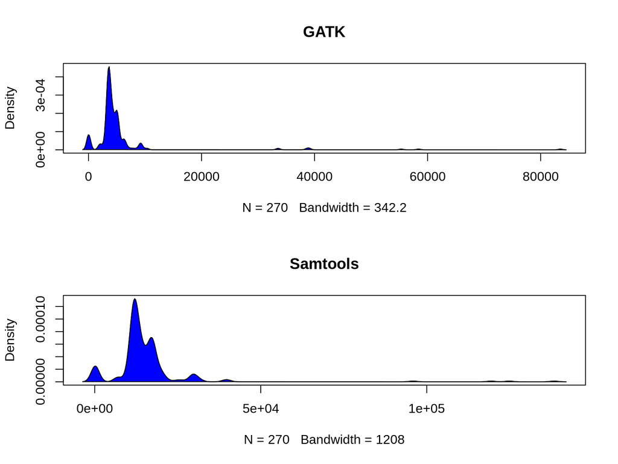

Eliminating the visually obvious outliers gives us a better picture of the overall correlation. There still appears to be a linear correlation, although the Samtools method has generated roughly three times as many SNPs.

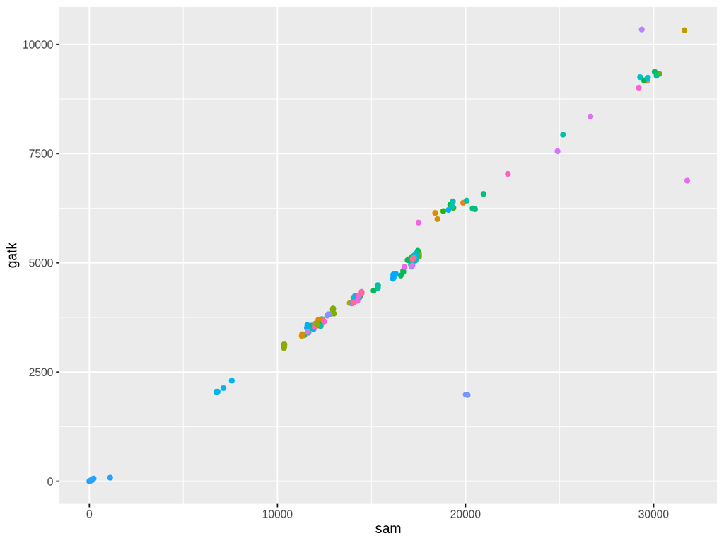

Dividing by 3 the number of SNPs called by Samtools, we get a plot with the same shape.

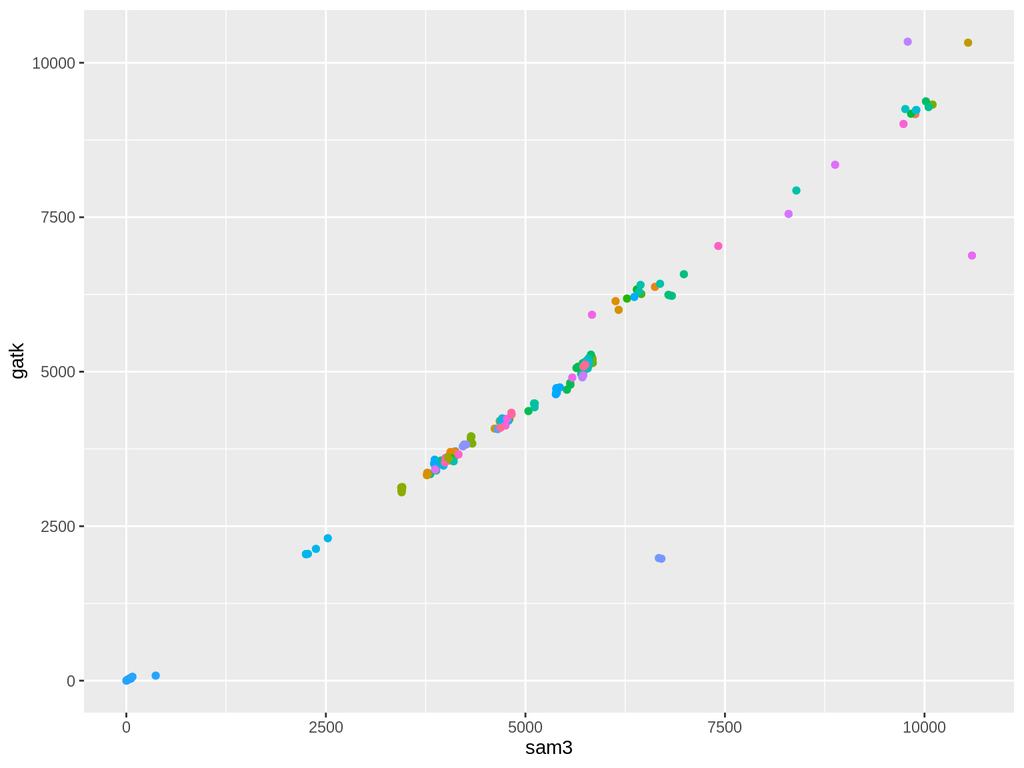

## Looking at the outliers

There are 8 visually-obvious outliers that we removed to generate the last graph.

One of these is the genome that the Samtools method couldn’t complete (Sal_JR3_62-z36_RKS2983). The de-duped bam file appears fine, and runs fine through the GATK pipeline (33,424 SNPs called). `bcftools mpileup` seems to generate a corrupt bcf file, and when `bcftools call` is run, it gives the error: ‘No BGZF EOF marker; file may be truncated.’

Interestingly, the three genomes with serotype code JEG called roughly the same number of SNPs for each method. I’m not sure what to think of this, since the Samtools method called 3x as many SNPs for most of the isolates.

```
##                          id    sam  gatk code
## 1        Sal_JEG_EC20121176  39072 38975  JEG
## 2        Sal_JEG_EC20121179  40164 39084  JEG
## 3        Sal_JEG_EC20121180  39744 38549  JEG
## 4           Sal_JR2_00-0163 124835 33662  JR2
## 5    Sal_JR3_62-z36_RKS2983      0 33424  JR3
## 6 Sal_JR3_62-z4-z23_RSK2980 138378 83503  JR3
## 7              Sal_JR6_1121 119402 58404  JR6
## 8           Sal_RN5_01-0170  95880 55336  RN5
##                                    Serotype
## 1                    Salmonella Enteritidis
## 2                    Salmonella Enteritidis
## 3                    Salmonella Enteritidis
## 4                  Salmonella subspecies II
## 5                Salmonella subspecies IIIa
## 6                Salmonella subspecies IIIa
## 7                  Salmonella subspecies VI
## 8 Salmonella subspecies IIIb 60:r:e,n,x,z15
```

Just for curiosity, I also identified the outliers via Cook’s distance. They are the same, with the exception that Sal_JR6_1121 is not on the list now. It seems that these samples are the ones that warrant a closer look.

```
##                            id    sam  gatk code
## 119        Sal_JEG_EC20121176  39072 38975  JEG
## 120        Sal_JEG_EC20121179  40164 39084  JEG
## 121        Sal_JEG_EC20121180  39744 38549  JEG
## 231           Sal_JR2_00-0163 124835 33662  JR2
## 232    Sal_JR3_62-z36_RKS2983      0 33424  JR3
## 233 Sal_JR3_62-z4-z23_RSK2980 138378 83503  JR3
## 245           Sal_RN5_01-0170  95880 55336  RN5
##                                      Serotype
## 119                    Salmonella Enteritidis
## 120                    Salmonella Enteritidis
## 121                    Salmonella Enteritidis
## 231                  Salmonella subspecies II
## 232                Salmonella subspecies IIIa
## 233                Salmonella subspecies IIIa
## 245 Salmonella subspecies IIIb 60:r:e,n,x,z15
```

I decided to incorporate the size of the bam as a proxy for the size of the sequence, to see if the outliers are different in this regard.

It is apparent that the outliers are 10-fold larger than the overall data.

```
## File size summary statistics for all samples
```

```
##      Min.   1st Qu.    Median      Mean   3rd Qu.      Max.
## 2.085e+05 8.715e+05 8.741e+05 1.724e+07 8.874e+05 1.881e+09
```

```
##
## File size summary statistics for outliers
```

```
##      Min.   1st Qu.    Median      Mean   3rd Qu.      Max.
## 3.518e+06 5.057e+06 6.756e+06 6.280e+08 1.247e+09 1.881e+09
```

A scatter plot color-coding size shows that the outliers are all files in the top 25% of the data. However, there are also many files in the top 25% that lie along the line. All the files in the middle 50% fall along the line, and most of the smallest 25% of files do as well. There are a few exceptions among the small files that we could examine further

```
##
##  small medium  large
##     68    134     68
```

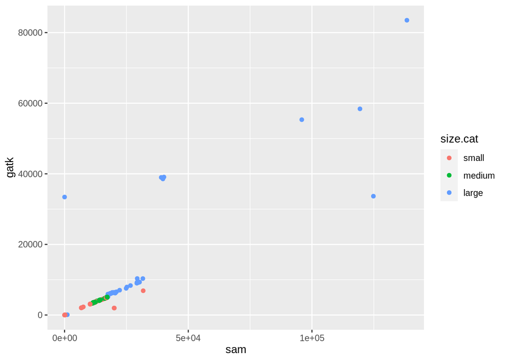

It is safe to say that, for this dataset, GATK and Samtools capture a proportionately appropriate number of SNPs for most samples. The exceptions are verry large files and some very small files. Things to look into:

1. Why Samtools captures 3x more SNPs on average than GATK.
2. What’s up with the very large files?